# Risk Factor Analysis

## Outcome Variable

**Outcome Variable:** wasted

## Predictor Variables

**Intervention Variable:** fage

**Adjustment Set:**

- arm
- W_mage
- meducyrs
- feducyrs
- W_mhtcm
- W_mwtkg
- W_mbmi
- W_fhtcm
- single
- brthmon
- delta_W_mage
- delta_meducyrs
- delta_feducyrs
- delta_W_mhtcm
- delta_W_mwtkg
- delta_W_mbmi
- delta_W_fhtcm
- delta_single
- delta_brthmon

## Stratifying Variables

The analysis was stratified on these variable(s):

- agecat
- studyid
- country

## Data Summary

| agecat | studyid | country | fage | wasted | n_cell | n |
| --- | --- | --- | --- | --- | --- | --- |
| Birth | ki0047075b-MAL-ED | BANGLADESH | >=38 | 0 | 50 | 128 |
| Birth | ki0047075b-MAL-ED | BANGLADESH | >=38 | 1 | 11 | 128 |
| Birth | ki0047075b-MAL-ED | BANGLADESH | <32 | 0 | 16 | 128 |
| Birth | ki0047075b-MAL-ED | BANGLADESH | <32 | 1 | 7 | 128 |
| Birth | ki0047075b-MAL-ED | BANGLADESH | [32-38) | 0 | 39 | 128 |
| Birth | ki0047075b-MAL-ED | BANGLADESH | [32-38) | 1 | 5 | 128 |
| Birth | ki0047075b-MAL-ED | BRAZIL | >=38 | 0 | 5 | 16 |
| Birth | ki0047075b-MAL-ED | BRAZIL | >=38 | 1 | 0 | 16 |
| Birth | ki0047075b-MAL-ED | BRAZIL | <32 | 0 | 1 | 16 |
| Birth | ki0047075b-MAL-ED | BRAZIL | <32 | 1 | 0 | 16 |
| Birth | ki0047075b-MAL-ED | BRAZIL | [32-38) | 0 | 10 | 16 |
| Birth | ki0047075b-MAL-ED | BRAZIL | [32-38) | 1 | 0 | 16 |
| Birth | ki0047075b-MAL-ED | INDIA | >=38 | 0 | 7 | 25 |
| Birth | ki0047075b-MAL-ED | INDIA | >=38 | 1 | 0 | 25 |
| Birth | ki0047075b-MAL-ED | INDIA | <32 | 0 | 6 | 25 |
| Birth | ki0047075b-MAL-ED | INDIA | <32 | 1 | 2 | 25 |
| Birth | ki0047075b-MAL-ED | INDIA | [32-38) | 0 | 7 | 25 |
| Birth | ki0047075b-MAL-ED | INDIA | [32-38) | 1 | 3 | 25 |
| Birth | ki0047075b-MAL-ED | NEPAL | >=38 | 0 | 2 | 9 |
| Birth | ki0047075b-MAL-ED | NEPAL | >=38 | 1 | 0 | 9 |
| Birth | ki0047075b-MAL-ED | NEPAL | <32 | 0 | 2 | 9 |
| Birth | ki0047075b-MAL-ED | NEPAL | <32 | 1 | 0 | 9 |
| Birth | ki0047075b-MAL-ED | NEPAL | [32-38) | 0 | 4 | 9 |
| Birth | ki0047075b-MAL-ED | NEPAL | [32-38) | 1 | 1 | 9 |
| Birth | ki0047075b-MAL-ED | PERU | >=38 | 0 | 23 | 67 |
| Birth | ki0047075b-MAL-ED | PERU | >=38 | 1 | 0 | 67 |
| Birth | ki0047075b-MAL-ED | PERU | <32 | 0 | 19 | 67 |
| Birth | ki0047075b-MAL-ED | PERU | <32 | 1 | 2 | 67 |
| Birth | ki0047075b-MAL-ED | PERU | [32-38) | 0 | 23 | 67 |
| Birth | ki0047075b-MAL-ED | PERU | [32-38) | 1 | 0 | 67 |

[output cut: 180 more lines]

The following strata were considered:

- agecat: 24 months, studyid: ki0047075b-MAL-ED, country: BANGLADESH
- agecat: 24 months, studyid: ki0047075b-MAL-ED, country: BRAZIL
- agecat: 24 months, studyid: ki0047075b-MAL-ED, country: INDIA
- agecat: 24 months, studyid: ki0047075b-MAL-ED, country: NEPAL
- agecat: 24 months, studyid: ki0047075b-MAL-ED, country: PERU
- agecat: 24 months, studyid: ki0047075b-MAL-ED, country: SOUTH AFRICA
- agecat: 24 months, studyid: ki0047075b-MAL-ED, country: TANZANIA, UNITED REPUBLIC OF
- agecat: 24 months, studyid: ki1119695-PROBIT, country: BELARUS
- agecat: 24 months, studyid: ki1135781-COHORTS, country: GUATEMALA
- agecat: 24 months, studyid: ki1135781-COHORTS, country: PHILIPPINES
- agecat: 24 months, studyid: ki1148112-LCNI-5, country: MALAWI
- agecat: 6 months, studyid: ki0047075b-MAL-ED, country: BANGLADESH
- agecat: 6 months, studyid: ki0047075b-MAL-ED, country: BRAZIL
- agecat: 6 months, studyid: ki0047075b-MAL-ED, country: INDIA
- agecat: 6 months, studyid: ki0047075b-MAL-ED, country: NEPAL
- agecat: 6 months, studyid: ki0047075b-MAL-ED, country: PERU
- agecat: 6 months, studyid: ki0047075b-MAL-ED, country: SOUTH AFRICA
- agecat: 6 months, studyid: ki0047075b-MAL-ED, country: TANZANIA, UNITED REPUBLIC OF
- agecat: 6 months, studyid: ki1000304b-SAS-CompFeed, country: INDIA
- agecat: 6 months, studyid: ki1000304b-SAS-FoodSuppl, country: INDIA
- agecat: 6 months, studyid: ki1119695-PROBIT, country: BELARUS
- agecat: 6 months, studyid: ki1135781-COHORTS, country: GUATEMALA
- agecat: 6 months, studyid: ki1135781-COHORTS, country: PHILIPPINES
- agecat: 6 months, studyid: ki1148112-LCNI-5, country: MALAWI
- agecat: Birth, studyid: ki0047075b-MAL-ED, country: BANGLADESH
- agecat: Birth, studyid: ki0047075b-MAL-ED, country: BRAZIL
- agecat: Birth, studyid: ki0047075b-MAL-ED, country: INDIA
- agecat: Birth, studyid: ki0047075b-MAL-ED, country: NEPAL
- agecat: Birth, studyid: ki0047075b-MAL-ED, country: PERU
- agecat: Birth, studyid: ki0047075b-MAL-ED, country: SOUTH AFRICA
- agecat: Birth, studyid: ki0047075b-MAL-ED, country: TANZANIA, UNITED REPUBLIC OF
- agecat: Birth, studyid: ki1000304b-SAS-CompFeed, country: INDIA
- agecat: Birth, studyid: ki1119695-PROBIT, country: BELARUS
- agecat: Birth, studyid: ki1135781-COHORTS, country: GUATEMALA
- agecat: Birth, studyid: ki1135781-COHORTS, country: PHILIPPINES

### Dropped Strata

Some strata were dropped due to rare outcomes:

- agecat: Birth, studyid: ki0047075b-MAL-ED, country: BRAZIL
- agecat: Birth, studyid: ki0047075b-MAL-ED, country: INDIA
- agecat: Birth, studyid: ki0047075b-MAL-ED, country: NEPAL
- agecat: Birth, studyid: ki0047075b-MAL-ED, country: PERU
- agecat: Birth, studyid: ki0047075b-MAL-ED, country: SOUTH AFRICA
- agecat: Birth, studyid: ki0047075b-MAL-ED, country: TANZANIA, UNITED REPUBLIC OF
- agecat: 6 months, studyid: ki0047075b-MAL-ED, country: BANGLADESH
- agecat: 6 months, studyid: ki0047075b-MAL-ED, country: BRAZIL
- agecat: 6 months, studyid: ki0047075b-MAL-ED, country: INDIA
- agecat: 6 months, studyid: ki0047075b-MAL-ED, country: NEPAL
- agecat: 6 months, studyid: ki0047075b-MAL-ED, country: PERU
- agecat: 6 months, studyid: ki0047075b-MAL-ED, country: SOUTH AFRICA
- agecat: 6 months, studyid: ki0047075b-MAL-ED, country: TANZANIA, UNITED REPUBLIC OF
- agecat: 6 months, studyid: ki1148112-LCNI-5, country: MALAWI
- agecat: 24 months, studyid: ki0047075b-MAL-ED, country: BANGLADESH
- agecat: 24 months, studyid: ki0047075b-MAL-ED, country: BRAZIL
- agecat: 24 months, studyid: ki0047075b-MAL-ED, country: INDIA
- agecat: 24 months, studyid: ki0047075b-MAL-ED, country: NEPAL
- agecat: 24 months, studyid: ki0047075b-MAL-ED, country: PERU
- agecat: 24 months, studyid: ki0047075b-MAL-ED, country: SOUTH AFRICA
- agecat: 24 months, studyid: ki0047075b-MAL-ED, country: TANZANIA, UNITED REPUBLIC OF
- agecat: 24 months, studyid: ki1119695-PROBIT, country: BELARUS
- agecat: 24 months, studyid: ki1148112-LCNI-5, country: MALAWI

## Methods Detail

We’re interested in the causal parameters $E[Y_a]$ for all values of $a \in \mathcal{A}$. These parameters represent the mean outcome if, possibly contrary to fact, we intervened to set all units to have $A=a$. Under the randomization and positivity assumptions, these are identified by the statistical parameters $\psi_a=E_W[E_{Y|A,W}(Y|A=a,W)]$. In addition, we’re interested in the mean of $Y$, $E[Y]$ under no intervention (the observed mean). We will estimate these parameters by using SuperLearner to fit the relevant likelihood factors – $E_{Y|A,W}(Y|A=a,W)$ and $p(A=a|W)$, and then updating our likelihood fit using a joint TMLE.

For unadjusted analyses ($W=\{\}$), initial likelihoods were estimated using Lrnr_glm to estimate the simple $E(Y|A)$ and Lrnr_mean to estimate $p(A)$. For adjusted analyses, a small library containing Lrnr_glmnet, Lrnr_xgboost, and Lrnr_mean was used.

Having estimated these parameters, we will then use the delta method to estimate relative risks and attributable risks relative to a prespecified baseline level of $A$.

# Results Detail

## Results Plots

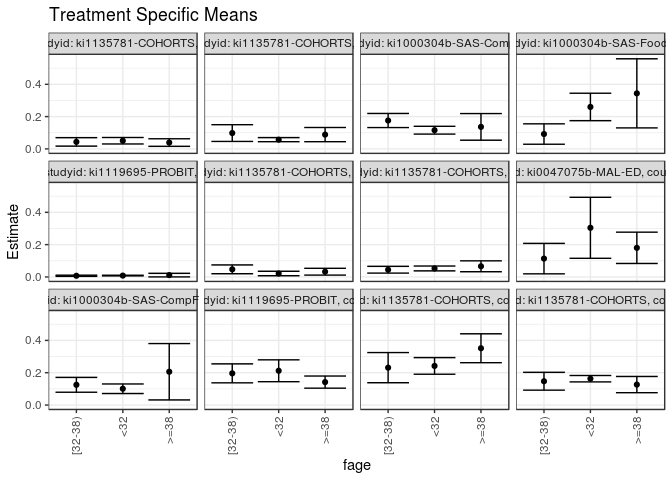

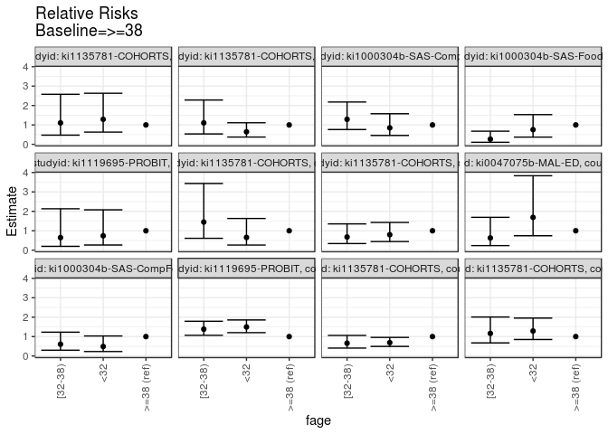

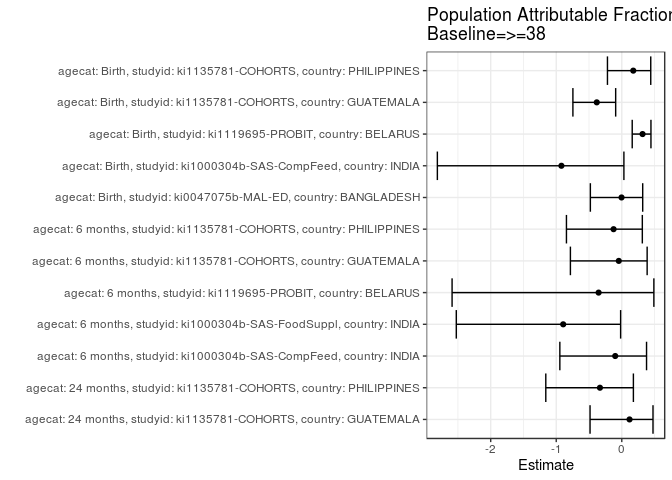

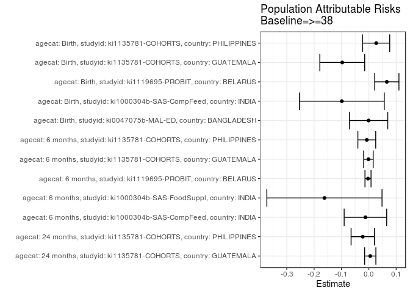

## Results Table

### Parameter: TSM

| agecat | studyid | country | intervention_level | baseline_level | estimate | ci_lower | ci_upper |
| --- | --- | --- | --- | --- | --- | --- | --- |
| Birth | ki0047075b-MAL-ED | BANGLADESH | >=38 | NA | 0.1803279 | 0.0834694 | 0.2771864 |
| Birth | ki0047075b-MAL-ED | BANGLADESH | <32 | NA | 0.3043478 | 0.1155624 | 0.4931333 |
| Birth | ki0047075b-MAL-ED | BANGLADESH | [32-38) | NA | 0.1136364 | 0.0194930 | 0.2077797 |
| Birth | ki1000304b-SAS-CompFeed | INDIA | >=38 | NA | 0.2058824 | 0.0314915 | 0.3802732 |
| Birth | ki1000304b-SAS-CompFeed | INDIA | <32 | NA | 0.1007584 | 0.0711101 | 0.1304067 |
| Birth | ki1000304b-SAS-CompFeed | INDIA | [32-38) | NA | 0.1250000 | 0.0790452 | 0.1709548 |
| Birth | ki1119695-PROBIT | BELARUS | >=38 | NA | 0.1418871 | 0.1042378 | 0.1795363 |
| Birth | ki1119695-PROBIT | BELARUS | <32 | NA | 0.2120563 | 0.1444160 | 0.2796965 |
| Birth | ki1119695-PROBIT | BELARUS | [32-38) | NA | 0.1960166 | 0.1373265 | 0.2547066 |
| Birth | ki1135781-COHORTS | GUATEMALA | >=38 | NA | 0.3514799 | 0.2620367 | 0.4409231 |
| Birth | ki1135781-COHORTS | GUATEMALA | <32 | NA | 0.2419767 | 0.1904106 | 0.2935429 |
| Birth | ki1135781-COHORTS | GUATEMALA | [32-38) | NA | 0.2313067 | 0.1379271 | 0.3246863 |
| Birth | ki1135781-COHORTS | PHILIPPINES | >=38 | NA | 0.1264726 | 0.0762152 | 0.1767299 |
| Birth | ki1135781-COHORTS | PHILIPPINES | <32 | NA | 0.1629905 | 0.1431979 | 0.1827831 |
| Birth | ki1135781-COHORTS | PHILIPPINES | [32-38) | NA | 0.1471131 | 0.0919035 | 0.2023226 |
| 6 months | ki1000304b-SAS-CompFeed | INDIA | >=38 | NA | 0.1363636 | 0.0538801 | 0.2188472 |
| 6 months | ki1000304b-SAS-CompFeed | INDIA | <32 | NA | 0.1158645 | 0.0916826 | 0.1400465 |
| 6 months | ki1000304b-SAS-CompFeed | INDIA | [32-38) | NA | 0.1757576 | 0.1320926 | 0.2194226 |
| 6 months | ki1000304b-SAS-FoodSuppl | INDIA | >=38 | NA | 0.3439003 | 0.1300154 | 0.5577852 |
| 6 months | ki1000304b-SAS-FoodSuppl | INDIA | <32 | NA | 0.2598105 | 0.1748419 | 0.3447791 |
| 6 months | ki1000304b-SAS-FoodSuppl | INDIA | [32-38) | NA | 0.0920527 | 0.0290073 | 0.1550980 |
| 6 months | ki1119695-PROBIT | BELARUS | >=38 | NA | 0.0114123 | 0.0003141 | 0.0225105 |
| 6 months | ki1119695-PROBIT | BELARUS | <32 | NA | 0.0084600 | 0.0064257 | 0.0104942 |
| 6 months | ki1119695-PROBIT | BELARUS | [32-38) | NA | 0.0073785 | 0.0038511 | 0.0109059 |
| 6 months | ki1135781-COHORTS | GUATEMALA | >=38 | NA | 0.0326087 | 0.0116437 | 0.0535737 |
| 6 months | ki1135781-COHORTS | GUATEMALA | <32 | NA | 0.0213777 | 0.0075538 | 0.0352015 |
| 6 months | ki1135781-COHORTS | GUATEMALA | [32-38) | NA | 0.0472103 | 0.0199632 | 0.0744574 |
| 6 months | ki1135781-COHORTS | PHILIPPINES | >=38 | NA | 0.0660885 | 0.0323999 | 0.0997772 |
| 6 months | ki1135781-COHORTS | PHILIPPINES | <32 | NA | 0.0526202 | 0.0377221 | 0.0675183 |
| 6 months | ki1135781-COHORTS | PHILIPPINES | [32-38) | NA | 0.0448822 | 0.0239611 | 0.0658034 |
| 24 months | ki1135781-COHORTS | GUATEMALA | >=38 | NA | 0.0392932 | 0.0159254 | 0.0626611 |
| 24 months | ki1135781-COHORTS | GUATEMALA | <32 | NA | 0.0506398 | 0.0307055 | 0.0705740 |
| 24 months | ki1135781-COHORTS | GUATEMALA | [32-38) | NA | 0.0433963 | 0.0172135 | 0.0695791 |
| 24 months | ki1135781-COHORTS | PHILIPPINES | >=38 | NA | 0.0886391 | 0.0446709 | 0.1326073 |
| 24 months | ki1135781-COHORTS | PHILIPPINES | <32 | NA | 0.0572450 | 0.0445483 | 0.0699418 |
| 24 months | ki1135781-COHORTS | PHILIPPINES | [32-38) | NA | 0.0980739 | 0.0462606 | 0.1498872 |

### Parameter: E(Y)

| agecat | studyid | country | intervention_level | baseline_level | estimate | ci_lower | ci_upper |
| --- | --- | --- | --- | --- | --- | --- | --- |
| Birth | ki0047075b-MAL-ED | BANGLADESH | NA | NA | 0.1796875 | 0.1129154 | 0.2464596 |
| Birth | ki1000304b-SAS-CompFeed | INDIA | NA | NA | 0.1071753 | 0.0763487 | 0.1380019 |
| Birth | ki1119695-PROBIT | BELARUS | NA | NA | 0.2077367 | 0.1424867 | 0.2729867 |
| Birth | ki1135781-COHORTS | GUATEMALA | NA | NA | 0.2544218 | 0.2229136 | 0.2859300 |
| Birth | ki1135781-COHORTS | PHILIPPINES | NA | NA | 0.1533786 | 0.1400217 | 0.1667355 |
| 6 months | ki1000304b-SAS-CompFeed | INDIA | NA | NA | 0.1239669 | 0.0988748 | 0.1490591 |
| 6 months | ki1000304b-SAS-FoodSuppl | INDIA | NA | NA | 0.1815789 | 0.1427684 | 0.2203895 |
| 6 months | ki1119695-PROBIT | BELARUS | NA | NA | 0.0084321 | 0.0066848 | 0.0101795 |
| 6 months | ki1135781-COHORTS | GUATEMALA | NA | NA | 0.0311828 | 0.0200060 | 0.0423596 |
| 6 months | ki1135781-COHORTS | PHILIPPINES | NA | NA | 0.0587338 | 0.0497323 | 0.0677353 |
| 24 months | ki1135781-COHORTS | GUATEMALA | NA | NA | 0.0445736 | 0.0319770 | 0.0571703 |
| 24 months | ki1135781-COHORTS | PHILIPPINES | NA | NA | 0.0664983 | 0.0564781 | 0.0765186 |

### Parameter: RR

| agecat | studyid | country | intervention_level | baseline_level | estimate | ci_lower | ci_upper |
| --- | --- | --- | --- | --- | --- | --- | --- |
| Birth | ki0047075b-MAL-ED | BANGLADESH | >=38 | >=38 | 1.0000000 | 1.0000000 | 1.0000000 |
| Birth | ki0047075b-MAL-ED | BANGLADESH | <32 | >=38 | 1.6877470 | 0.7429438 | 3.8340588 |
| Birth | ki0047075b-MAL-ED | BANGLADESH | [32-38) | >=38 | 0.6301653 | 0.2347772 | 1.6914263 |
| Birth | ki1000304b-SAS-CompFeed | INDIA | >=38 | >=38 | 1.0000000 | 1.0000000 | 1.0000000 |
| Birth | ki1000304b-SAS-CompFeed | INDIA | <32 | >=38 | 0.4893979 | 0.2320405 | 1.0321919 |
| Birth | ki1000304b-SAS-CompFeed | INDIA | [32-38) | >=38 | 0.6071429 | 0.3005726 | 1.2264006 |
| Birth | ki1119695-PROBIT | BELARUS | >=38 | >=38 | 1.0000000 | 1.0000000 | 1.0000000 |
| Birth | ki1119695-PROBIT | BELARUS | <32 | >=38 | 1.4945428 | 1.2028047 | 1.8570415 |
| Birth | ki1119695-PROBIT | BELARUS | [32-38) | >=38 | 1.3814972 | 1.0662615 | 1.7899310 |
| Birth | ki1135781-COHORTS | GUATEMALA | >=38 | >=38 | 1.0000000 | 1.0000000 | 1.0000000 |
| Birth | ki1135781-COHORTS | GUATEMALA | <32 | >=38 | 0.6884511 | 0.4942559 | 0.9589463 |
| Birth | ki1135781-COHORTS | GUATEMALA | [32-38) | >=38 | 0.6580937 | 0.4086350 | 1.0598388 |
| Birth | ki1135781-COHORTS | PHILIPPINES | >=38 | >=38 | 1.0000000 | 1.0000000 | 1.0000000 |
| Birth | ki1135781-COHORTS | PHILIPPINES | <32 | >=38 | 1.2887422 | 0.8505005 | 1.9527989 |
| Birth | ki1135781-COHORTS | PHILIPPINES | [32-38) | >=38 | 1.1632013 | 0.6733827 | 2.0093140 |
| 6 months | ki1000304b-SAS-CompFeed | INDIA | >=38 | >=38 | 1.0000000 | 1.0000000 | 1.0000000 |
| 6 months | ki1000304b-SAS-CompFeed | INDIA | <32 | >=38 | 0.8496732 | 0.4582271 | 1.5755168 |
| 6 months | ki1000304b-SAS-CompFeed | INDIA | [32-38) | >=38 | 1.2888889 | 0.7620445 | 2.1799704 |
| 6 months | ki1000304b-SAS-FoodSuppl | INDIA | >=38 | >=38 | 1.0000000 | 1.0000000 | 1.0000000 |
| 6 months | ki1000304b-SAS-FoodSuppl | INDIA | <32 | >=38 | 0.7554819 | 0.3728846 | 1.5306419 |
| 6 months | ki1000304b-SAS-FoodSuppl | INDIA | [32-38) | >=38 | 0.2676725 | 0.1058555 | 0.6768527 |
| 6 months | ki1119695-PROBIT | BELARUS | >=38 | >=38 | 1.0000000 | 1.0000000 | 1.0000000 |
| 6 months | ki1119695-PROBIT | BELARUS | <32 | >=38 | 0.7413039 | 0.2644251 | 2.0782123 |
| 6 months | ki1119695-PROBIT | BELARUS | [32-38) | >=38 | 0.6465386 | 0.1961028 | 2.1315976 |
| 6 months | ki1135781-COHORTS | GUATEMALA | >=38 | >=38 | 1.0000000 | 1.0000000 | 1.0000000 |
| 6 months | ki1135781-COHORTS | GUATEMALA | <32 | >=38 | 0.6555819 | 0.2633944 | 1.6317271 |
| 6 months | ki1135781-COHORTS | GUATEMALA | [32-38) | >=38 | 1.4477825 | 0.6102174 | 3.4349634 |
| 6 months | ki1135781-COHORTS | PHILIPPINES | >=38 | >=38 | 1.0000000 | 1.0000000 | 1.0000000 |
| 6 months | ki1135781-COHORTS | PHILIPPINES | <32 | >=38 | 0.7962081 | 0.4442968 | 1.4268554 |
| 6 months | ki1135781-COHORTS | PHILIPPINES | [32-38) | >=38 | 0.6791228 | 0.3405510 | 1.3542986 |
| 24 months | ki1135781-COHORTS | GUATEMALA | >=38 | >=38 | 1.0000000 | 1.0000000 | 1.0000000 |
| 24 months | ki1135781-COHORTS | GUATEMALA | <32 | >=38 | 1.2887661 | 0.6313834 | 2.6306012 |
| 24 months | ki1135781-COHORTS | GUATEMALA | [32-38) | >=38 | 1.1044218 | 0.4731977 | 2.5776700 |
| 24 months | ki1135781-COHORTS | PHILIPPINES | >=38 | >=38 | 1.0000000 | 1.0000000 | 1.0000000 |
| 24 months | ki1135781-COHORTS | PHILIPPINES | <32 | >=38 | 0.6458216 | 0.3750567 | 1.1120598 |
| 24 months | ki1135781-COHORTS | PHILIPPINES | [32-38) | >=38 | 1.1064410 | 0.5359713 | 2.2840994 |

### Parameter: PAR

| agecat | studyid | country | intervention_level | baseline_level | estimate | ci_lower | ci_upper |
| --- | --- | --- | --- | --- | --- | --- | --- |
| Birth | ki0047075b-MAL-ED | BANGLADESH | >=38 | NA | -0.0006404 | -0.0706280 | 0.0693473 |
| Birth | ki1000304b-SAS-CompFeed | INDIA | >=38 | NA | -0.0987071 | -0.2538955 | 0.0564814 |
| Birth | ki1119695-PROBIT | BELARUS | >=38 | NA | 0.0658497 | 0.0215351 | 0.1101642 |
| Birth | ki1135781-COHORTS | GUATEMALA | >=38 | NA | -0.0970582 | -0.1790847 | -0.0150316 |
| Birth | ki1135781-COHORTS | PHILIPPINES | >=38 | NA | 0.0269061 | -0.0226185 | 0.0764306 |
| 6 months | ki1000304b-SAS-CompFeed | INDIA | >=38 | NA | -0.0123967 | -0.0901578 | 0.0653644 |
| 6 months | ki1000304b-SAS-FoodSuppl | INDIA | >=38 | NA | -0.1623214 | -0.3729019 | 0.0482592 |
| 6 months | ki1119695-PROBIT | BELARUS | >=38 | NA | -0.0029801 | -0.0140535 | 0.0080933 |
| 6 months | ki1135781-COHORTS | GUATEMALA | >=38 | NA | -0.0014259 | -0.0188492 | 0.0159974 |
| 6 months | ki1135781-COHORTS | PHILIPPINES | >=38 | NA | -0.0073548 | -0.0399712 | 0.0252617 |
| 24 months | ki1135781-COHORTS | GUATEMALA | >=38 | NA | 0.0052804 | -0.0152316 | 0.0257925 |
| 24 months | ki1135781-COHORTS | PHILIPPINES | >=38 | NA | -0.0221408 | -0.0648174 | 0.0205359 |

### Parameter: PAF

| agecat | studyid | country | intervention_level | baseline_level | estimate | ci_lower | ci_upper |
| --- | --- | --- | --- | --- | --- | --- | --- |
| Birth | ki0047075b-MAL-ED | BANGLADESH | >=38 | NA | -0.0035638 | -0.4794487 | 0.3192462 |
| Birth | ki1000304b-SAS-CompFeed | INDIA | >=38 | NA | -0.9209870 | -2.8138686 | 0.0324284 |
| Birth | ki1119695-PROBIT | BELARUS | >=38 | NA | 0.3169861 | 0.1592824 | 0.4451074 |
| Birth | ki1135781-COHORTS | GUATEMALA | >=38 | NA | -0.3814853 | -0.7457654 | -0.0932177 |
| Birth | ki1135781-COHORTS | PHILIPPINES | >=38 | NA | 0.1754224 | -0.2185501 | 0.4420187 |
| 6 months | ki1000304b-SAS-CompFeed | INDIA | >=38 | NA | -0.1000000 | -0.9449871 | 0.3778879 |
| 6 months | ki1000304b-SAS-FoodSuppl | INDIA | >=38 | NA | -0.8939439 | -2.5249902 | -0.0175981 |
| 6 months | ki1119695-PROBIT | BELARUS | >=38 | NA | -0.3534237 | -2.5892294 | 0.4896521 |
| 6 months | ki1135781-COHORTS | GUATEMALA | >=38 | NA | -0.0457271 | -0.7839164 | 0.3869975 |
| 6 months | ki1135781-COHORTS | PHILIPPINES | >=38 | NA | -0.1252219 | -0.8442804 | 0.3134860 |
| 24 months | ki1135781-COHORTS | GUATEMALA | >=38 | NA | 0.1184654 | -0.4841813 | 0.4764095 |
| 24 months | ki1135781-COHORTS | PHILIPPINES | >=38 | NA | -0.3329524 | -1.1593896 | 0.1771925 |